# Visualizing Violent Crime in Washington, D.C.

To visualize how similar or different these census tracts are, we then plot their calculated coordinates and color their position by which cluster they belong to. We also label each of our outliers to see how similar or different they are from census tracts with violent crime rates that are not as extreme. From our plot, we see that our outliers (tracts with exceptionally high violent crime rates) are generally similar to other tracts in the Washington, D.C.

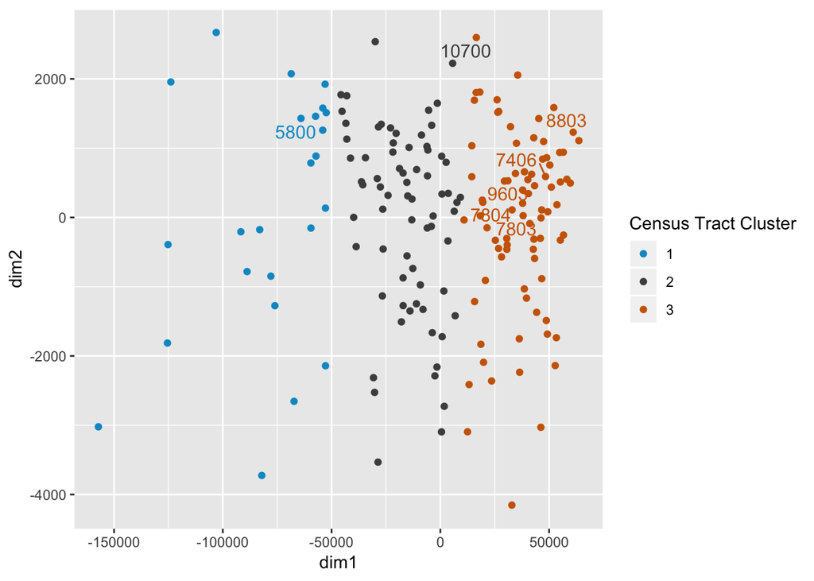

```r
base = ggplot(coordinates, aes(x = dim1, y = dim2, color = factor(cluster))) +
          scale_color_manual(values = c("deepskyblue3","grey30","darkorange3"),
                             name = "Census Tract Cluster")

clust1 = base + geom_point() + geom_text_repel(aes(label=ifelse(census_tract %in% outliers,
                                                                census_tract,"")),
                                               size = 4, show.legend = FALSE)
clust1
```

As a final step, let’s add our titles and formatting as usual, but let’s also get rid of the x and y-axes. The plot represents the relative distance of points to one another, but the specific coordinate values themselves offer no meanngful information.

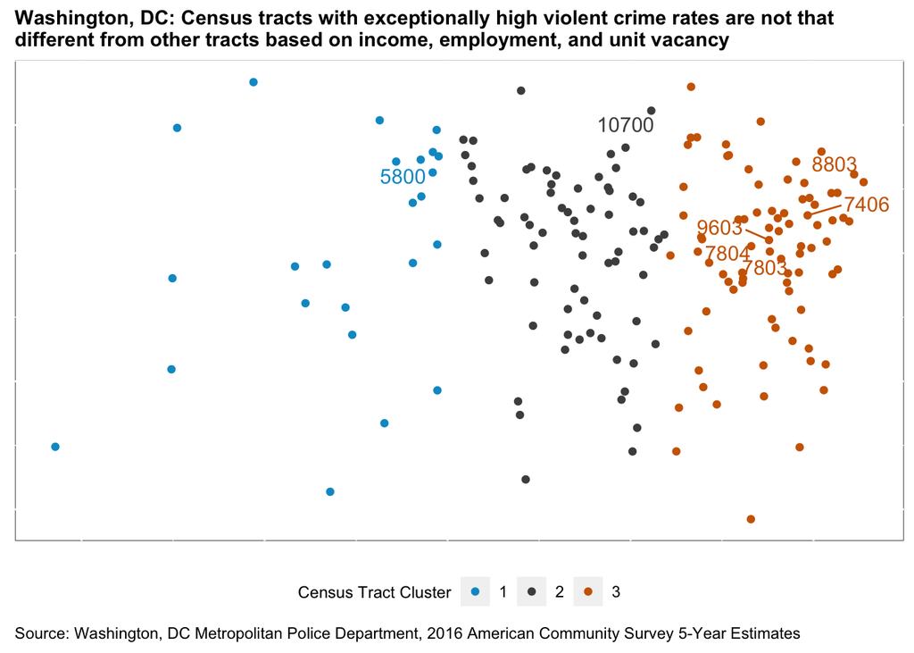

```r
title = "Washington, DC: Census tracts with exceptionally high violent crime rates are not that \ndifferent from other tracts based on income, employment, and unit vacancy"
caption = "Source: Washington, DC Metropolitan Police Department, 2016 American Community Survey 5-Year Estimates"

clust2 = clust1 + labs(title = title,
                       caption = caption)

clust3 = clust2 + theme(panel.background = element_rect(fill = "white", color = "grey50"),
                        axis.title = element_blank(),
                        axis.text = element_blank(),
                        axis.ticks = element_blank(),
                        plot.title = element_text(size = 11, face = "bold"),
                        legend.title = element_text(size = 9),
                        legend.position = "bottom",
                        plot.caption = element_text(hjust = 0))

clust3
```

But we’re still curious as to what tract-level characteristics, if any, may be a good predictor of violent crime. To do this we want to perform a regression analysis. We’re interested in comparing coefficient estimates and making interpretation of these estimates a bit easier, so we log-transform each variable in our simple model. However, to ensure that our data doesn’t give us any issues when trying to run our analysis, we create a copy of our data frame, drop any tracts with missing data, and replace any values equal to 0 to now be equal to 0.01 to allow for the log transformation.

```r
regdf <- census_violent[complete.cases(census_violent),]
regdf <- apply(regdf, 2, function(x) ifelse(x==0,0.01,x))
regdf <- as.data.frame(regdf)
```

We then estimate a regression model predicting the tract violent crime rate based on the tract total population, household median income, and vacancy rate and output a summary of our results.

```r
modelA <- lm(log(vcrate) ~ log(total_pop) + log(hh_med_income) + log(vacancy_rate),
              data = regdf)

summary(modelA)
```

```
##
## Call:
## lm(formula = log(vcrate) ~ log(total_pop) + log(hh_med_income) +
##     log(vacancy_rate), data = regdf)
##
## Residuals:
##      Min       1Q   Median       3Q      Max
## -10.3380  -0.1899   0.3060   0.7991   2.6203
##
## Coefficients:
##                    Estimate Std. Error t value Pr(>|t|)
## (Intercept)         23.5808     4.2474   5.552 1.05e-07 ***
## log(total_pop)      -0.4156     0.3934  -1.056    0.292
## log(hh_med_income)  -1.3031     0.2540  -5.129 7.78e-07 ***
## log(vacancy_rate)    0.1160     0.1921   0.604    0.547
## ---
## Signif. codes:  0 '***' 0.001 '**' 0.01 '*' 0.05 '.' 0.1 ' ' 1
##
## Residual standard error: 1.89 on 172 degrees of freedom
## Multiple R-squared:  0.1674, Adjusted R-squared:  0.1529
## F-statistic: 11.53 on 3 and 172 DF,  p-value: 6.328e-07
```

We store these results in a table for our use later and create a field called naming the model that was just estimated.

```r
modelA_t <- tidy(modelA) %>% mutate(model = "No Employment Control")
```

We then prepare a second regression model, this time adding a control for the unemployment rate, and output a summary of these results.

```r
modelB <- lm(log(vcrate) ~ log(total_pop) + log(hh_med_income) + log(unemp_rate) + log(vacancy_rate),
              data = regdf)

summary(modelB)
```

```
##
## Call:
## lm(formula = log(vcrate) ~ log(total_pop) + log(hh_med_income) +
##     log(unemp_rate) + log(vacancy_rate), data = regdf)
##
## Residuals:
##     Min      1Q  Median      3Q     Max
## -9.8801 -0.3202  0.2410  0.7941  3.4590
##
## Coefficients:
##                    Estimate Std. Error t value Pr(>|t|)
## (Intercept)        11.77415    5.36105   2.196 0.029421 *
## log(total_pop)     -0.43838    0.38165  -1.149 0.252306
## log(hh_med_income) -0.36604    0.36722  -0.997 0.320275
## log(unemp_rate)     0.86991    0.25278   3.441 0.000727 ***
## log(vacancy_rate)   0.03272    0.18785   0.174 0.861938
## ---
## Signif. codes:  0 '***' 0.001 '**' 0.01 '*' 0.05 '.' 0.1 ' ' 1
##
## Residual standard error: 1.833 on 171 degrees of freedom
## Multiple R-squared:  0.2214, Adjusted R-squared:  0.2032
## F-statistic: 12.15 on 4 and 171 DF,  p-value: 1.02e-08
```

Again, we store these results in a table, but this time, append it to the table with the model results from our model without the unemployment rate control.

```r
modelB_t <- tidy(modelB) %>% mutate(model = "Employment Control")
allmodels <- rbind(modelB_t, modelA_t)
```

We’d like to see how the addition of the unemployment rate control affected the coefficient estimates on the other variables in the model. Let’s start by creating a plot of the coefficient estimates and the 95% confidence intervals around each estimate. We’ll add a dashed line at zero to indicate which coefficient estimates include zero within the confidence interval (implying the estimated effect is not statistically significant).

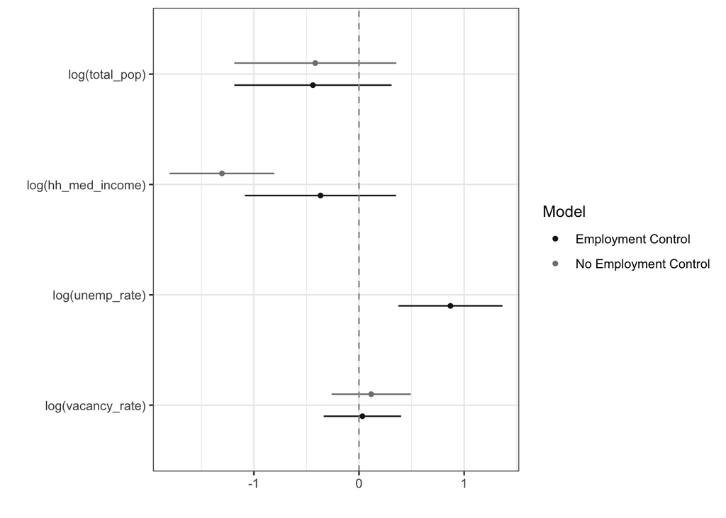

```r
plot1 = dwplot(allmodels) +
            geom_vline(xintercept = 0,
               colour = "grey60",
               linetype = 2) +
            scale_colour_grey(start = .1, end = .5, name="Model") + theme_bw()
plot1
```

Let’s add our titles and source, as usual.

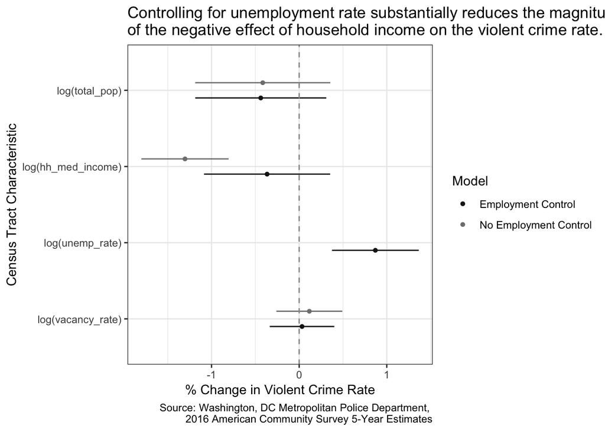

```r
title = "Controlling for unemployment rate substantially reduces the magnitude \nof the negative effect of household income on the violent crime rate."
caption = "Source: Washington, DC Metropolitan Police Department, \n2016 American Community Survey 5-Year Estimates"

plot2 = plot1 + labs(title = title,
                     x = "% Change in Violent Crime Rate",
                     y = "Census Tract Characteristic",
                     caption = caption)
plot2
```

We see we still need to clean this plot up a bit. Let’s start by specifying what we want on our axes and then adding our normal formatting. We see that without controlling for the unemployment rate, household median income was the lone strong predictor of violent crime in our model. However, by controlling for unemployment rate, we see that the effect of median household income is effectively eliminated and that the unemployment rate becomes a strong predictor of violent crime. This is consistent with what we saw in the correlation plot, where household median income and the unemployment rate were strongly correlated. This could suggest that unemployment rate is perhaps a strong driver of violent crime and the effect of household median income by itself is largely driven by the level of unemployment in the tract.

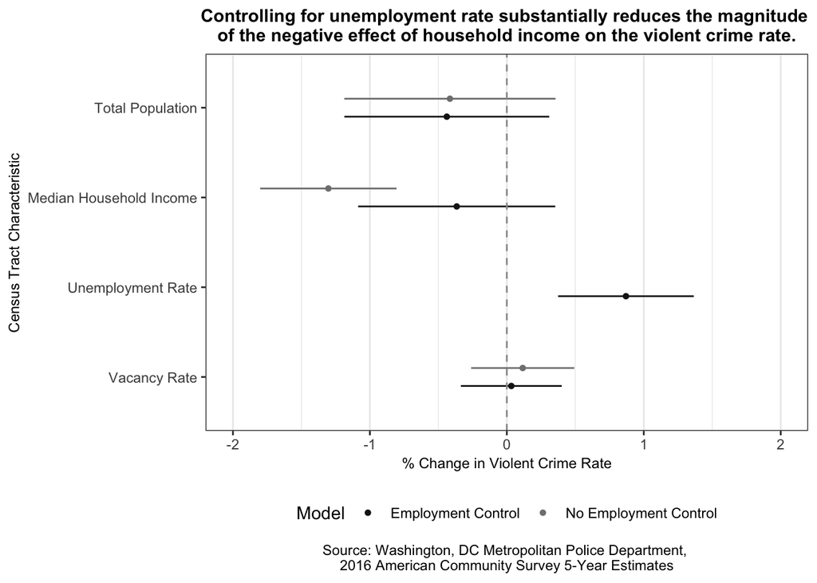

```r
plot3 = plot2 + scale_y_discrete(labels = c("Vacancy Rate",
                                            "Unemployment Rate",
                                            "Median Household Income",
                                            "Total Population")) +
                scale_x_continuous(breaks = c(-2,-1,0,1,2), limits = c(-2,2))

plot4 = plot3 + theme(panel.grid.major.y = element_blank(),
                      plot.title = element_text(size = 11, face = "bold", hjust = 0.5),
                      axis.title = element_text(size = 9),
                      plot.caption = element_text(hjust = 0.5),
                      legend.position = "bottom")

plot4
```